# Hospitals HUC Analysis

The purpose of the code presented in this document is to determine how many hospitals have potential exposures to PFAS through proximity to potential PFAS points sources, and how many people are impacted. Towards this end, the code:

1. Loads the .gpkg files created in `get_HUC_elevation.Rmd`
2. Joins hospitals data to data representing the locations of each potential point source based on a shared HUC-12 code
3. Filters to hospitals at a lower elevation than a potential point source as a proxy for hydrological flow direction
4. Calculates the number of unique hospitals in the same HUC-12 watershed boundary and at a lower elevation than each point source and a combination of point sources, along with the number of people potentially impacted

## Load point sources with HUC-12 and elevations

All of these files were created in `get_HUC_elevation.Rmd`.

```r
hospital_huc_elevation <- st_read("huc_elevation_datasets/hospital_HUC_elevation_block.gpkg") %>%
    mutate(POPULATION = na_if(POPULATION, -999)) %>%
  filter(STATUS != "CLOSED") %>%
  mutate(REGION = case_when(
    STATE %in% c("CA", "WA", "OR", "HI", "AK") ~ "PACIFIC",
    STATE %in% c("AZ", "CO", "ID", "NM", "MT", "UT", "NV", "WY") ~ "MOUNTAIN",
    STATE %in% c("IA", "KS", "MN", "MO", "NE","ND", "SD") ~ "WEST NORTH CENTRAL",
    STATE %in% c("IN", "IL", "MI", "OH", "WI") ~ "EAST NORTH CENTRAL",
    STATE %in% c("AR", "LA", "OK", "TX") ~ "WEST SOUTH CENTRAL",
    STATE %in% c("AL", "KY", "MS", "TN") ~ "EAST SOUTH CENTRAL",
    STATE %in% c("NJ", "NY", "PA") ~ "MID ATLANTIC",
    STATE %in% c("MA", "CT", "RI", "VT", "NH", "ME") ~ "NEW ENGLAND",
    STATE %in% c("DE", "DC", "GA", "MD", "NC", "SC", "VA", "WV", "FL") ~ "SOUTH ATLANTIC",
    TRUE ~ "OUTLYING"
    ))
hospital_huc_elevation_urban <- hospital_huc_elevation %>%
  filter(URBAN == "URBAN")

susp_cont_huc_elevation <- st_read("huc_elevation_datasets/susp_cont_HUC_elevation.gpkg") %>%
  mutate(Source = case_when(Source == "Formerly Used Defense Sites" |
                     Source == "Military Installations, Ranges, and Training Areas" ~ "Military Installment",
                   TRUE ~ Source))
pfas_huc_elevation <- st_read("huc_elevation_datasets/pfas_huc_elevation.gpkg") %>%
  mutate(industry = case_when(
    industry == "Military" ~ "Military Installment",
    industry == "Landfill" ~ "Industrial Facilities",
    industry == "Industry" ~ "Industrial Facilities",
    industry == "Fire Department/Training Facility" ~ "Industrial Facilities",
    industry == "Airport" ~ "Major Airports (FAA Part 139)",
    industry == "Unknown" ~ "Other",
    industry == "WWTP" ~ "Wastewater Treatment Plants",
    industry == "Superfund Site" ~ "Industrial Facilities",
    industry == "Dry Cleaner" ~ "Industrial Facilities",
    industry == "Waste" ~ "Waste",
    industry == "Other" ~ "Other"
  ))
```

```r
missing_pop <-
  hospital_huc_elevation %>%
  st_drop_geometry() %>%
  mutate(MISSING_POPULATION = case_when(is.na(POPULATION) ~ 1,
                             TRUE ~ 0)) %>%
  summarize(Total = n(),
            Count_Missing_Pop = sum(MISSING_POPULATION),
            Percent_Missing_Pop = Count_Missing_Pop/n()*100)
```

## Presumptive and Known Point Source Analysis

### Join Known Point Sources to Hospitals with Shared HUC-12

```r
hospital_pfas_joined <-
  hospital_huc_elevation %>%
  select(-elev_units) %>%
  rename(ELEVATION_HOSPITAL = elevation,
         INDEX_HOSPITAL = Index) %>%
  st_set_geometry(NULL) %>%
  inner_join(pfas_huc_elevation %>%
                 st_set_geometry(NULL),
               by = "HUC") %>%
    filter(ELEVATION_HOSPITAL < elevation) %>%
    rename(PFAS_ID_COLUMN = map_id,
           PFAS_NAME = site_name,
           PFAS_INDUSTRY = industry,
           PFAS_SOURCE = suspected_source,
           PFAS_STATE = state,
           PFAS_LEVEL = pfas_level) %>%
    select(ID, NAME, POPULATION, URBAN, STATE, REGION, PFAS_ID_COLUMN, PFAS_NAME, PFAS_INDUSTRY, PFAS_SOURCE, PFAS_LEVEL, LATITUDE, LONGITUDE)
```

### Calculate Numbers and Percentages of Hospitals in Proximity to Different Thresholds of Point Sources

Purpose:

This code calculates the number, percentage, and populations of hospitals in the same HUC-12 and at a lower elevation than each point source. The previous code produced a data frame in which a hospital may have been listed multiple times if there was more than one point source in the same HUC-12 and at a higher elevation. This code reduces the file to unique hospitals by grouping variables specific to the facility. It then counts the number of observations in the data frame, the percentage of the total hospitals in the US this number represents, and the number of people potentially impacted. Specifically, it

- groups rows representing the same hospital,
- filters to groups in which the number of observations (in this case representing proximate point sources) is greater than the threshold,
- selects variables related to hospitals and subsets to distinct hospitals

After this, the same calculations are performed as those performed above.

```r
point_source_calculation <- function(source, threshold, text) {
  source %>%
  group_by(ID) %>%
  filter(n() > threshold) %>%
  ungroup() %>%
  select(ID, POPULATION, URBAN) %>%
  distinct() %>%
  summarize(HOSPITAL_WITH_POINT_SOURCE_IN_HUC = n(),
            PERC_HOSPITAL_WITH_POINT_SOURCE_IN_HUC = n() / nrow(hospital_huc_elevation) * 100,
            AT_LEAST_HOSPITAL_WITH_POINT_SOURCE_IN_HUC = sum(POPULATION, na.rm = TRUE),
            URBAN_HOSPITAL_WITH_POINT_SOURCE_IN_HUC = sum(URBAN == "URBAN"),
            PERC_URBAN_HOSPITAL_WITH_POINT_SOURCE_IN_HUC = sum(URBAN == "URBAN") / nrow(hospital_huc_elevation_urban) * 100,
            AT_LEAST_URBAN_WITH_POINT_SOURCE_IN_HUC = sum(POPULATION[URBAN == "URBAN"], na.rm = TRUE),
            NON_URBAN_HOSPITAL_WITH_POINT_SOURCE_IN_HUC = sum(URBAN != "URBAN"),
            PERC_NON_URBAN_HOSPITAL_WITH_POINT_SOURCE_IN_HUC = sum(URBAN != "URBAN") / (nrow(hospital_huc_elevation) - nrow(hospital_huc_elevation_urban)) * 100,
            AT_LEAST_NON_URBAN_WITH_POINT_SOURCE_IN_HUC = sum(POPULATION[URBAN != "URBAN"], na.rm = TRUE)) %>%
  mutate(SUSP_CONT_SOURCE = paste("More than", threshold, text, "point sources" )) %>%
  relocate(SUSP_CONT_SOURCE, .before = HOSPITAL_WITH_POINT_SOURCE_IN_HUC)
}

at_least_one_susp_source <- point_source_calculation(hospital_susp_cont_joined, 0, "presumptive")
more_than_one_susp_source <- point_source_calculation(hospital_susp_cont_joined, 1, "presumptive")
more_than_five_susp_source <- point_source_calculation(hospital_susp_cont_joined, 5, "presumptive")
at_least_one_known_source <- point_source_calculation(hospital_pfas_joined, 0, "known")
more_than_one_known_source <- point_source_calculation(hospital_pfas_joined, 1, "known")
more_than_five_known_source <- point_source_calculation(hospital_pfas_joined, 5, "known")

totals_table_hospital <-
  rbind(at_least_one_susp_source,
        more_than_one_susp_source,
        more_than_five_susp_source,
        at_least_one_known_source,
        more_than_one_known_source,
        more_than_five_known_source)

write.csv(totals_table_hospital, "final_datasets/totals_table_hospital.csv")

rm(at_least_one_susp_source,
   more_than_one_susp_source,
   more_than_five_susp_source,
   at_least_one_known_source,
   more_than_one_known_source,
   more_than_five_known_source
)
```

### Perform Presumptive Point Source Calculations by Region

```r
facility_region_totals <-
  hospital_huc_elevation %>%
  st_drop_geometry() %>%
  group_by(REGION) %>%
  summarize(REGION_COUNT = n(),
            POP_COUNT = sum(POPULATION, na.rm = TRUE))

by_region_table <- function(source){

  hosp_at_least_one <-
    source %>%
    select(ID, POPULATION, REGION) %>%
    distinct()

  by_hosp_region <-
    hosp_at_least_one %>%
    left_join(facility_region_totals, by = "REGION") %>%
    group_by(REGION) %>%
    summarize(HOSP_WITH_POINT_SOURCE_IN_HUC = n(),
              PERC_HOSP_DENOM_TOTAL_IN_HUC =
                n() / nrow(hosp_at_least_one) * 100,
              PERC_HOSP_DENOM_TOTAL_OF_REGION =
                n() / REGION_COUNT * 100,
              AT_LEAST_HOSP_POP_WITH_POINT_SOURCE_IN_HUC =
                sum(POPULATION, na.rm = TRUE)) %>%
    distinct()


}

susp_by_hosp_region <- by_region_table(hospital_susp_cont_joined)
known_by_hosp_region <- by_region_table(hospital_pfas_joined)
write.csv(susp_by_hosp_region, "final_datasets/susp_by_hosp_region.csv")
write.csv(known_by_hosp_region, "final_datasets/known_by_hosp_region.csv")
```

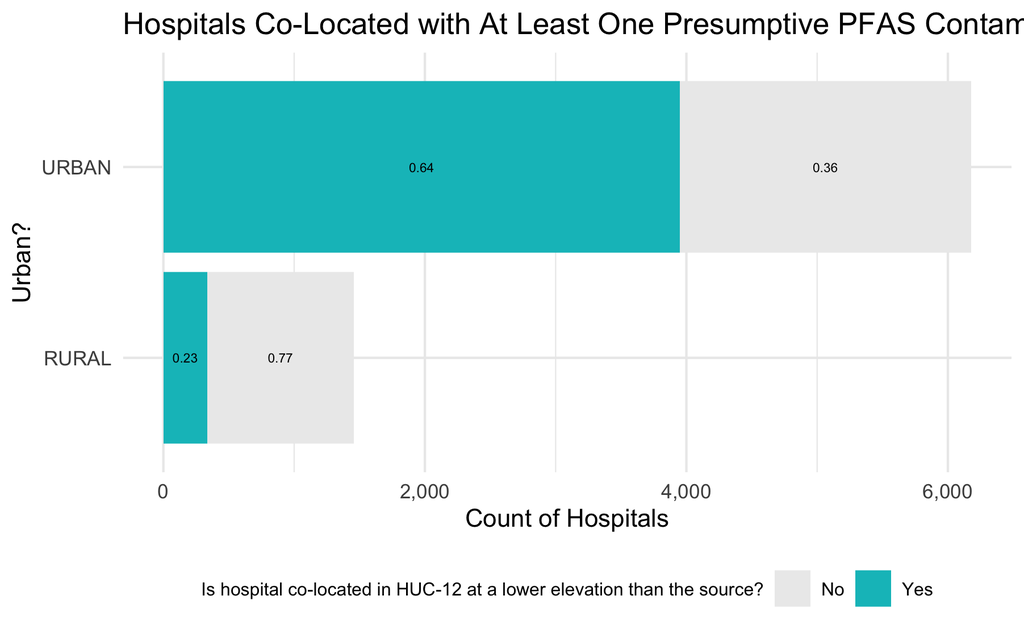

```r
hospital_susp_cont_joined %>%
  mutate(DENOM = case_when(URBAN == "URBAN" ~
                             nrow(hospital_huc_elevation %>%
                                    filter(URBAN == "URBAN")),
                           TRUE ~
                             nrow(hospital_huc_elevation %>%
                                    filter(URBAN != "URBAN")))) %>%
  select(ID, URBAN, DENOM) %>%
  distinct() %>%
  group_by(URBAN) %>%
  summarize(Yes = n(),
            No = DENOM - n(),
            DENOM = DENOM) %>%
  distinct() %>%
  ungroup() %>%
  pivot_longer(Yes:No,
    names_to = "COLOCATED",
    values_to = "COUNT") %>%
  mutate(Per = COUNT/DENOM) %>%
  ggplot(aes(x = URBAN, y = COUNT, group = COLOCATED)) +
  geom_col(aes(fill = COLOCATED)) +
  coord_flip() +
  scale_y_continuous(labels = scales::comma) +
  theme_minimal() +
  labs(title = "Hospitals Co-Located with At Least One Presumptive PFAS Contamination Source", x = "Urban?", y = "Count of Hospitals", fill = "Is hospital co-located in HUC-12 at a lower elevation than the source?") +
  theme(legend.position = "bottom", legend.title = element_text(size = 8), legend.text = element_text(size = 8)) +
  scale_fill_manual(values=c("#ececec", "#00bfc4")) +
  geom_text(aes(label = round(Per, 2)),
            colour = "black",
            size = 2,
            position = position_stack(vjust = 0.5))
```